# 5_Clustering precio electricidad, hora y demanda

# Nota: Los resultados corresponden a el apartado del trabajo 2.6.2. K-means precio medio, hora y demanda

# 5. Clustering precios electricidad, hora y demanda

```r
#Nota: se utilizan variables y data frames creados en el archivo 1_Analisis univariable y preprocesado por lo tanto se debe ejecutar primero este archivo
#Creamos data frame seleccionando solo los datos objeto de estudio (hora, demanda y precio medio)
clus_h<-electricity_prices[,c("Hour", "PM", "dem")]
clus_h1<-clus_h
```

```r
#Normalizamos las variables para evitar las bias producidas por las diferentes escalas (k-means se basa en distancias, por lo tanto debemos normalizar las variables)
clus_h1[,c("Hour")]<-(clus_h$Hour-mean(clus_h$Hour))/sd(clus_h$Hour)
clus_h1[,c("PM")]<-(clus_h$PM-mean(clus_h$PM))/sd(clus_h$PM)
clus_h1[,c("dem")]<-(clus_h$dem-mean(clus_h$dem))/sd(clus_h$dem)
```

# 5.1. Con semilla seed = 345

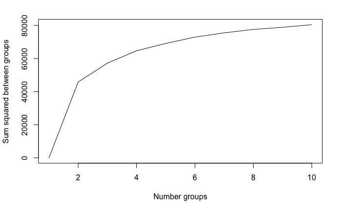

```r
#Fijamos una semilla que marcara la aleatoriedad (345). Si se modifica los resultados podrian cambiar.
#El objetivo con la eleccion de K es minimizar la dentro del grupo y maxmizar la entre grupos, representamos graficamente los resultados
set.seed(345)
bss_h<-kmeans(clus_h1, centers=1)$betweenss
for(i in 2:10) bss_h[i] <-kmeans(clus_h1, centers=i)$betweenss
plot(1:10, bss_h, type="l", xlab="Number groups", ylab="Sum squared between groups")
```

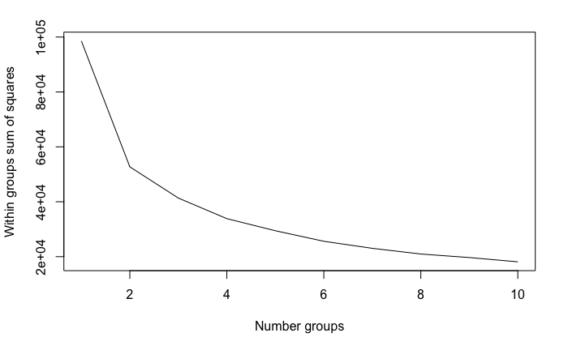

```r
set.seed(345)
bss_h1<-kmeans(clus_h1, centers=1)$tot.withinss
for(i in 2:10) bss_h1[i] <-kmeans(clus_h1, centers=i)$tot.withinss
plot(1:10, bss_h1, type="l", xlab="Number groups", ylab="Within groups sum of squares")
```

Parece que la solucion mas optima se encuentra entre 3 y 4 centros. A partir de 4 la mejora en sum squared between groups es insignificante.

```r
#Probamos la version de k-means con 3 centros
set.seed(345)
clush_k3<-kmeans(clus_h1, centers=3)
clush_k3$centers
```

```
        Hour         PM        dem
1 -0.1335209 -1.7431695 -0.5847617
2 -1.0499790 -0.1009401 -0.9418925
3  0.6317333  0.4852345  0.6807766
```

```r
#Observamos la media con los valores sin estandarizar
aggregate(clus_h, by=list(clush_k3$cluster), mean)
```

| Group.1 | Hour | PM | dem |
| --- | --- | --- | --- |
| 1 | 11.576031 | 17.84508 | 25711.07 |
| 2 | 5.232126 | 43.36142 | 24080.81 |
| 3 | 16.873273 | 52.46918 | 31488.10 |

```r
#Comprobamos la suma de cuadrados entre grupos
clush_k3$betweenss
```

```
[1] 55594.71
```

```r
#Realizamos k-means con 4 centros
set.seed(345)
clush_k4<-kmeans(clus_h1, centers=4)
clush_k4$centers
```

```
        Hour          PM        dem
1 -0.6892851 -1.89520724 -0.9375321
2 -1.0660406 -0.04365944 -0.9202543
3  0.3771089  0.88152010  0.9846119
4  0.9261818 -0.21984266  0.2071980
```

```r
#Observamos la media con los valores sin estandarizar
aggregate(clus_h, by=list(clush_k4$cluster), mean)
```

| Group.1 | Hour | PM | dem |
| --- | --- | --- | --- |
| 1 | 7.728921 | 15.48277 | 24100.72 |
| 2 | 5.120944 | 44.25142 | 24179.59 |
| 3 | 15.110712 | 58.62651 | 32875.07 |
| 4 | 18.911503 | 41.51395 | 29326.27 |

```r
#Observamos la suma de cuadrados entre grupos
clush_k4$betweenss
```

```
[1] 64718.61
```

La suma de cuadrados ha aumentado 9123.9 respecto a la solucion con 3 clusters

Interpretacion clusters: Cluster 1: manana, precio medio bajo Cluster 2: madrugada, precio medio intermedio Cluster 3: tarde, precio medio alto Cluster 4: noche, precio medio intermedio

```r
#Realizamos k-means con 5 centros
set.seed(345)
clush_k5<-kmeans(clus_h1, centers=5)
clush_k5$centers
```

```
        Hour           PM        dem
1 -0.9674073 -1.735426184 -1.1945144
2 -1.0580200  0.005278988 -0.9042837
3  1.1425861  0.352299327  0.1564116
4  0.5377995 -1.014196256  0.3673599
5  0.2423471  0.862921189  1.0725773
```

```r
#Observamos la suma de cuadrados entre grupos
clush_k5$betweenss
```

```
[1] 69257.1
```

La suma de cuadrados se in crementado en 4538.5 respecto la solucion anterior (aproximadamente la mitad que entre tres y 4 centros)

```r
#Comprobamos los resultados sin estandarizar
aggregate(clus_h, by=list(clus1_k5$cluster), mean)
```

[output not shown]

Interpretacion clusters: Cluster 1: manana, precio medio bajo Cluster 2: madrugada, precio medio intermedio Cluster 3: noche, precio medio alto Cluster 4: tarde, precio medio bajo Cluster 5: mediodia, precio medio alto

# Escogemos la solucion con 4 clusters y realizamos un analisis detallado de los diferentes clusters

# 5.1.2. Interpretacion k-means con k =4

```r
#Observamos cuantas observaciones caen en cada cluster
clus_h$cluster<-clush_k4$cluster #A??adimos una columna en los datos con e numero de cluster
table(clus_h$cluster)
```

```
    1     2     3     4
 3475  9616 10306  9458
```

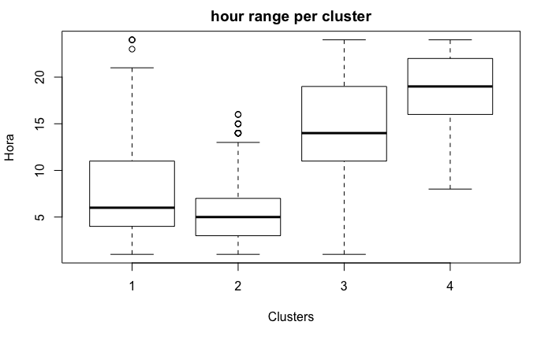

```r
boxplot(clus_h$Hour~clus_h$cluster, main="hour range per cluster", ylab= "Hora", xlab= "Clusters")
```

Como se ha comentado anteriormente: - Cluster 1: manana - Cluster 2: madrugada - Cluster 3: tarde - Cluster 4: noche (evening)

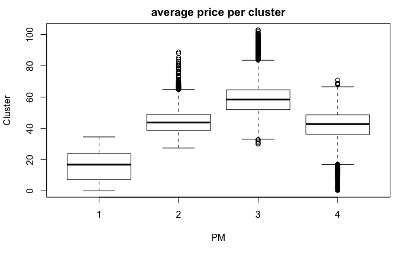

```r
boxplot(electricity_prices$PM~clus_h$cluster, main ="average price per cluster", xlab="PM", ylab= "Cluster")
```

[figure not shown]

```r
boxplot(electricity_prices$Hour~clus1_k5$cluster, main="Hour distribution by cluster")
```

```r
#Creamos una columna con las nuevas variables categoricas donde nombramos los clusters segun las partes del dia que predominan
clus_hour<-clus_h
clus_hour$DayPart1<-ifelse(clush_k4$cluster==1, "morning",
                                   ifelse(clush_k4$cluster==2, "night&early morning"
                                          , ifelse(clush_k4$cluster==3,
                                                   "afternoon",
                                                          "evening")))
```

```r
#Ordenamos los resultados
clus_hour$DayPart1<-factor(clus_hour$DayPart1, c("morning","afternoon", "evening", "night&early morning"))
```

```r
#Creamos tabla de frecuencia para ver cuantas observaciones caen en cada cluster
table(clus_hour$DayPart1)
```

```
            morning           afternoon             evening night&early morning
               3475               10306                9458                9616
```

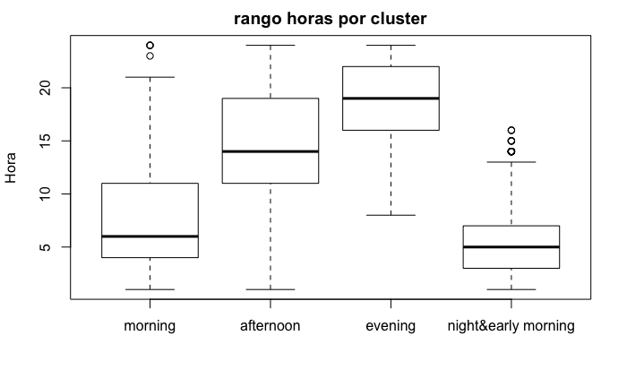

```r
#Creamos boxplot para ver la distribucion segun horas
boxplot(hour~clus_hour$DayPart1, main="rango horas por cluster", ylab= "Hora")
```

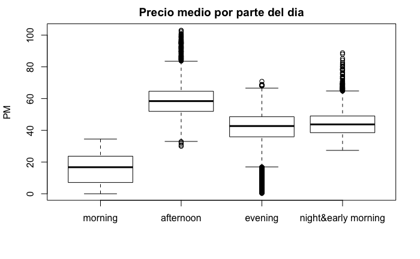

```r
#Creamos boxplot para observar la distribucion por precio
boxplot(PM~clus_hour$DayPart1, main ="Precio medio por parte del dia", ylab= "PM")
```

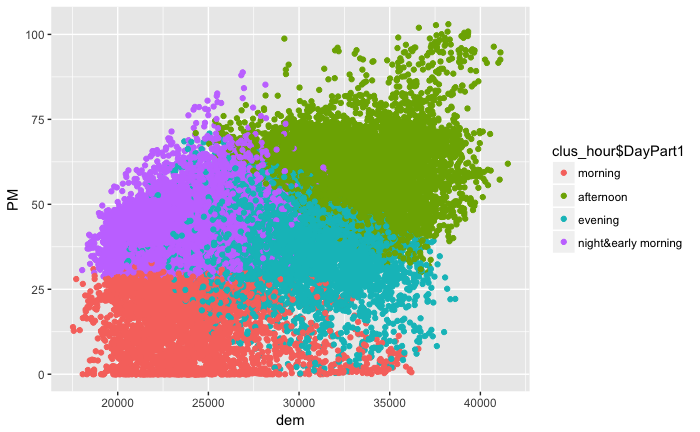

```r
# Analizamos visualmente los resultados con un grafico de dispersion de demanda y precio, marcando los clusters con colores diferentes
f_clus_h<-ggplot(electricity_prices, aes(x=dem, y=PM, col=clus_hour$DayPart1))+geom_point()
f_clus_h
```

Conclusion: los precios mas altos se producen durante el mediodia (intervalo 10h-14h) y la tarde-noche. Los precios mas bajos se producen durante las primeras horas de la manana.

# 5.2. Con semilla Seed = 1234

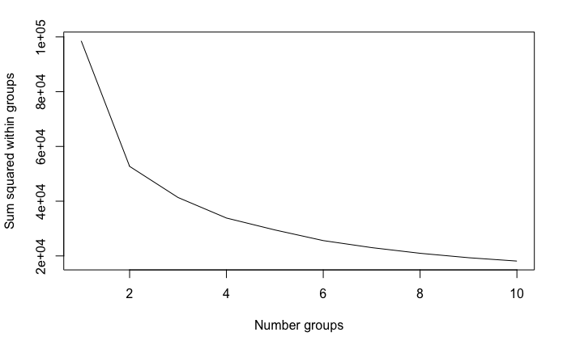

```r
#Realizamos k-means cambiando la semilla a 1234. Primero observamos el decremento en suma de cuadrados dentro de los grupos
set.seed(1234)
bss_h2<-kmeans(clus_h1, centers=1)$tot.withinss
for(i in 2:10) bss_h2[i] <-kmeans(clus_h1, centers=i)$tot.withinss
plot(1:10, bss_h2, type="l", xlab="Number groups", ylab="Sum squared within groups")
```

La solucion optima sigue siendo de 4 centros

```r
#K-means con 4 centros
set.seed(1234)
clush1_k4<-kmeans(clus_h1, centers=4)
clush1_k4$centers
```

```
        Hour          PM        dem
1  0.3771089  0.88152010  0.9846119
2  0.9261818 -0.21984266  0.2071980
3 -0.6892851 -1.89520724 -0.9375321
4 -1.0660406 -0.04365944 -0.9202543
```

```r
#Observamos la media con los valores sin estandarizar
aggregate(clus_h, by=list(clush1_k4$cluster), mean)
```

| Group.1 | Hour | PM | dem | cluster |
| --- | --- | --- | --- | --- |
| 1 | 15.110712 | 58.62651 | 32875.07 | 3 |
| 2 | 18.911503 | 41.51395 | 29326.27 | 4 |
| 3 | 7.728921 | 15.48277 | 24100.72 | 1 |
| 4 | 5.120944 | 44.25142 | 24179.59 | 2 |

Interpretacion clusters:

Cluster 1: mediodia-tarde, precio muy alto Cluster 2: noche, precio intermedio Cluster 3: manana, precio muy bajo Cluster 4: madrugada, precio intermedio

Los resultados son identicos a los anteriores pero con el orden de los clusters cambiado

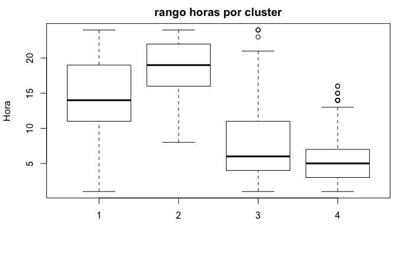

```r
#Creamos boxplot para ver la distribucion segun horas
boxplot(hour~clush1_k4$cluster, main="rango horas por cluster", ylab= "Hora")
```

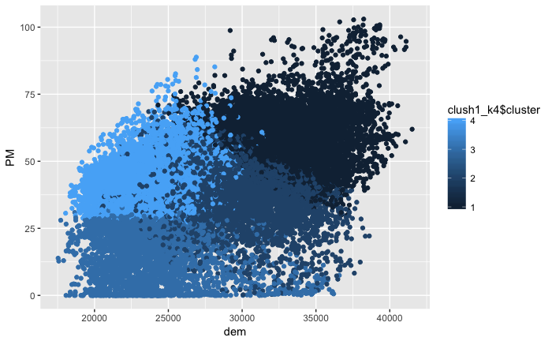

```r
#Observamos la distribucion de los clusters segun precio y demanda
library(ggplot2)
f_clus_h1<-ggplot(electricity_prices, aes(x=dem, y=PM, col=clush1_k4$cluster))+geom_point()
f_clus_h1
```

Estos resultados nos indican que, en este caso, modificar la semilla no influye en la distribucion de las observaciones en los grupos, elige las mismas soluciones.

# 5.3. Creacion de grupos de acuerdo con la solucion de k-means = 4

```r
#Creamos dummy para diferenciar manana, mediodia-tarde, noche y madrugada (morning, midday_afternoon, evening y night) y comprobar si existen diferencias en los grupos.
Morning<-ifelse(electricity_prices$Hour>=8&electricity_prices$Hour<12,
   1,
   0)
```

```r
Midday_Afternoon<-ifelse(electricity_prices$Hour>=12&electricity_prices$Hour<19,
   1,
   0)
```

```r
Evening<-ifelse(electricity_prices$Hour>=19&electricity_prices$Hour<24,
   1,
   0)
```

```r
Night_early_morning<-ifelse(electricity_prices$Hour>=24|electricity_prices$Hour<8,
   1,
   0)
```

```r
#Creamos data frame con precio, demanda y partes del dia
clus1<-electricity_prices[,c("PM", "dem")]
clus1$morning<-Morning
clus1$midday_afternoon<-Midday_Afternoon
clus1$evening<-Evening
clus1$night_early_morning<-Night_early_morning
```

```r
#Observamos las variables de data frame creado
summary(clus1)
```

```
       PM              dem           morning       midday_afternoon    evening       night_early_morning
 Min.   :  0.00   Min.   :17534   Min.   :0.0000   Min.   :0.0000   Min.   :0.0000   Min.   :0.0000
 1st Qu.: 37.23   1st Qu.:24477   1st Qu.:0.0000   1st Qu.:0.0000   1st Qu.:0.0000   1st Qu.:0.0000
 Median : 45.97   Median :28641   Median :0.0000   Median :0.0000   Median :0.0000   Median :0.0000
 Mean   : 44.93   Mean   :28380   Mean   :0.1667   Mean   :0.2917   Mean   :0.2083   Mean   :0.3333
 3rd Qu.: 54.74   3rd Qu.:31866   3rd Qu.:0.0000   3rd Qu.:1.0000   3rd Qu.:0.0000   3rd Qu.:1.0000
 Max.   :103.01   Max.   :41514   Max.   :1.0000   Max.   :1.0000   Max.   :1.0000   Max.   :1.0000
```

```r
#Estandarizamos las varibles
clus_1<-clus1 #Copiamos el objeto antes de modificarlo
clus1[,c("PM")]<-(clus1$PM-mean(clus1$PM))/sd(clus1$PM)
clus1[,c("dem")]<-(clus1$dem-mean(clus1$dem))/sd(clus1$dem)
clus1[,c("morning")]<-(clus1$morning-mean(clus1$morning))/sd(clus1$morning)
clus1[,c("midday_afternoon")]<-(clus1$midday_afternoon-mean(clus1$midday_afternoon))/sd(clus1$midday_afternoon)
clus1[,c("evening")]<-(clus1$evening-mean(clus1$evening))/sd(clus1$evening)
clus1[,c("night_early_morning")]<-(clus1$night_early_morning-mean(clus1$night_early_morning))/sd(clus1$night_early_morning)
```

```r
#Buscamos numero optimo de clusters
set.seed(123)
bss1<-kmeans(clus1, centers=1)$tot.withinss
for(i in 2:10) bss1[i] <-kmeans(clus1, centers=i)$tot.withinss
```

```
Quick-TRANSfer stage steps exceeded maximum (= 1642750)
```

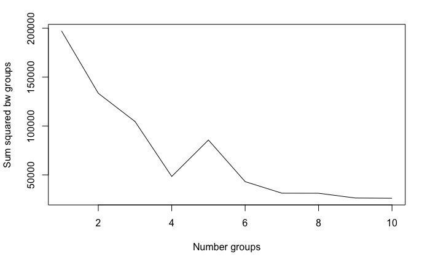

```r
plot(1:10, bss1, type="l", xlab="Number groups", ylab="Sum squared bw groups")
```

El numero optimo de clusters es 4, a partir de 4, se produce un aumento y una posterior mejora insignificante.

```r
set.seed(123)
clus1_k4<-kmeans(clus1, centers=4)
clus1_k4$centers
```

```
          PM        dem   morning midday_afternoon    evening night_early_morning
1  0.1078073  0.5543146 -0.447215         1.558330 -0.5129912          -0.7070637
2 -0.3899849 -0.9186210 -0.447215        -0.641693 -0.5129912           1.4142566
3  0.3384197  0.5825231 -0.447215        -0.641693  1.9492917          -0.7070637
4  0.1682111  0.1388698  2.235993        -0.641693 -0.5129912          -0.7070637
```

```r
aggregate(clus_1, by=list(clus1_k4$cluster), mean)
```

| Group.1 | PM | dem | morning | midday_afternoon | evening | night_early_morning |
| --- | --- | --- | --- | --- | --- | --- |
| 1 | 46.60485 | 30910.81 | 0 | 1 | 0 | 0 |
| 2 | 38.87035 | 24187.05 | 0 | 0 | 0 | 1 |
| 3 | 50.18802 | 31039.58 | 0 | 0 | 1 | 0 |
| 4 | 47.54339 | 29014.36 | 1 | 0 | 0 | 0 |

El modelo k-means nos clasifica cada parte del dia en un cluster diferente. Interpretacion clusters: - Cluster 1: mediodia-tarde, demanda alta, precio medio - Cluster 2: noche-madrugada, demanda baja, precio bajo - Cluster 3: tarde-noche, demanda muy alta, precio alto - Cluster 4: ma??ana, demanda malta, precio medio

```r
#Observamos observaciones en cada cluster
table(clus1_k4$cluster)
```

```
    1     2     3     4
 9583 10951  6845  5476
```

Cluster con mas observaciones: 2 (precio bajo, demanda baja)

```r
#Creamos variable categorica con parte dia
part_day<-ifelse(clus_1$morning==1, "morning",
                 ifelse(clus_1$midday_afternoon==1, "md_afternoon",
                        ifelse(clus_1$evening==1, "evening","night_e_m")))
```

```r
#Ordenamos parte del dia
part_day<-factor(part_day, c("morning", "md_afternoon", "evening", "night_e_m"))
```

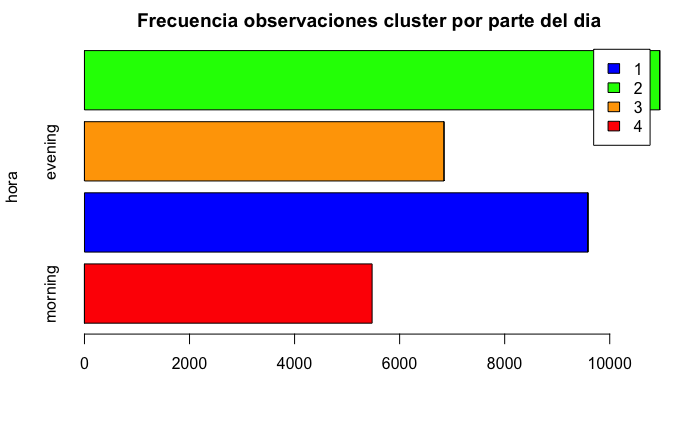

```r
#Observamos visualmente la distribucion por meses
counts_pd <- table(clus1_k4$cluster, part_day)
barplot(counts_pd, main="Frecuencia observaciones cluster por parte del dia", horiz=TRUE,
  ylab="hora", col=c("blue", "green", "orange", "red"),
    legend = rownames(counts_pd))
```

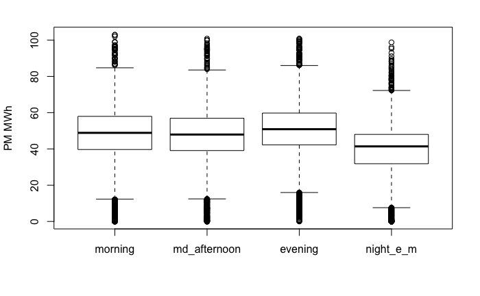

```r
#Realizamos boxplot con precios
boxplot(PM~part_day, ylab= "PM MWh")
```

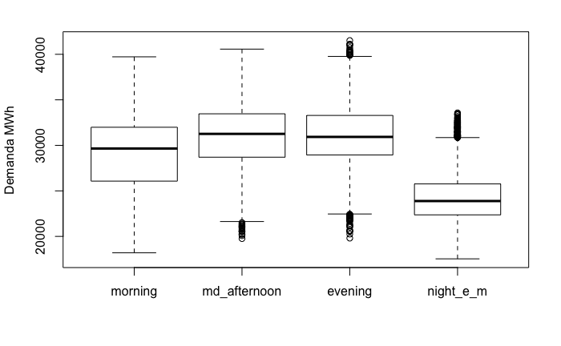

```r
#Realizamos boxplot con demanda
boxplot(ep$dem~part_day, ylab= "Demanda MWh")
```